# Using papeR with Markdown

Benjamin Hofner

# Using **papeR** – A short tutorial

This is a short tutorial that covers some of the main features of the R package **papeR**.

The main goal of the package is to ease statistical reporting and thus to ease reproducible research. By relying on powerful tools such as the `Sweave`, or the packages **knitr** and **xtable**, the package can be easily integrated in existing workflows.

- First of all, the package provides an infrastructure to handle variable labels which are used in all other functions (`labels()`).
- The package allows to create (complex) summary tables of the data sets (`summarize()`) and to easily plot the data (`plot()` for labeled `data.frame`s).
- Finally, the package allows to enhance summary tables of statistical models by (possibly) adding confidence intervals, significance stars, odds ratios, etc. and by separating variable names and factor levels (`prettify()`).

## Getting started

Before we start, we need to install the package. The package can be easily obtained from [CRAN](https://CRAN.R-project.org/package=papeR), e.g. via the command

```r
install.packages("papeR")
```

To install the latest development version, one can use **devtools** to install packages from [GitHub](https://github.com/hofnerb/papeR). Therefore we need to install and load **devtools** before we can install **papeR**:

```r
install.packages("devtools")
library("devtools")
install_github("hofnerb/papeR")
```

Now we can load the package

```r
library("papeR")
```

## The package

### Labeled data frames

To be able to use *all* features of the package, we first need to create a labeled data frame. We need labeled data frames to use the special `plot()` function (see below). All other functions do not strictly require labeled data frames but can exploit the labels.

Labels in **papeR** are stored as attributes of the variables, i.e., each variable in a labeld data frame has an attribute `"variable.label"`, and the data set gets an additional class `'ldf'`. Other packages store variable labels differently. E.g. the function `read.spss()` from the package **foreign** stores variable labels as a single attribute of the data set. The package **papeR** is also capable of using these labels. For details see the section “Conversion to labeled data frames”.

#### Setting and extracting labels

If we create a new `data.frame` we can extract and set variable labels using the function `labels()`. We use the `Orthodont` data package **nlme** throughout this tutorial. First load the data

```r
data(Orthodont, package = "nlme")
## keep the original data set for later use
Orthodont_orig <- Orthodont
```

To check if the data set is a labeled data set (i.e., of class `'ldf'`), we can use

```r
is.ldf(Orthodont)
```

```
## [1] FALSE
```

Despite the fact that we do not have a labeled data frame, we can query the labels. In this case, we simply get the variable names as no labels were set so far

```r
labels(Orthodont)
```

```
##   distance        age    Subject        Sex
## "distance"      "age"  "Subject"      "Sex"
```

This is a convenient feature, as we thus can relly on the fact that we will always have *some* variable labels.

To explicitly set labels, which are usually more descriptive than the variable names, we can simply assign a vector of labels. We use some of the information which is given on the help page of the `Orthodont` data and use it as labels:

```r
labels(Orthodont) <- c("fissure distance (mm)", "age (years)", "Subject", "Sex")
```

If we now query if `Orthodont` is a labeled data frame and extract the labels, we get

```r
is.ldf(Orthodont)
```

```
## [1] TRUE
```

```r
class(Orthodont)
```

```
## [1] "ldf"            "nfnGroupedData" "nfGroupedData"  "groupedData"
## [5] "data.frame"
```

We see that by setting variable labels, we also add the class `'ldf'` to the data frame. Now, the labels are

```r
labels(Orthodont)
```

```
##                distance                     age                 Subject
## "fissure distance (mm)"           "age (years)"               "Subject"
##                     Sex
##                   "Sex"
```

#### Advanced labelling

We can also set or ectract labels for a subset of the variables using the option `which`, which can either be a vector of variable names or indices. Let’s capitalize the labels of `distance` and `age` to make it consitent with `Subject` and `Sex`:

```r
## set labels for distance and age
labels(Orthodont, which = c("distance", "age")) <- c("Fissure distance (mm)", "Age (years)")
## extract labels for age only
labels(Orthodont, which = "age")
```

```
##           age
## "Age (years)"
```

```r
## or for the first two variables (i.e., distance and age)
labels(Orthodont, which = 1:2)
```

```
##                distance                     age
## "Fissure distance (mm)"           "Age (years)"
```

#### Conversion to labeled data frames

Instead of manually setting labels, we can simply convert a data frame to a labeled data frame, either with the function `as.ldf()` or with `convert.labels()`. Actually, both calls reference the same function (for an object of class `data.frame`).

While `as.ldf()` can be seen as the classical counterpart of `is.ldf()`, the function name `convert.labels()` is inspired by the fact that these functions either convert the variable names to labels or convert other variable labels to **papeR**-type variable labels. Hence, these functions can, for example, be used to convert labels from data sets which are imported via the function `read.spss()` to **papeR**-type variable labels.

If no variable labels are specified, the original variable names are used.

```r
Orthodont2 <- convert.labels(Orthodont_orig)
class(Orthodont2)
```

```
## [1] "ldf"            "nfnGroupedData" "nfGroupedData"  "groupedData"
## [5] "data.frame"
```

```r
labels(Orthodont2)
```

```
##   distance        age    Subject        Sex
## "distance"      "age"  "Subject"      "Sex"
```

### Plotting labeled data frames

For data frames of class `'ldf'`, there exist special plotting functions:

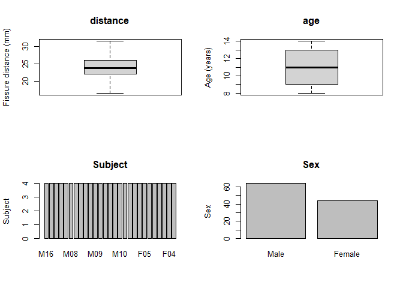

```r
par(mfrow = c(2, 2))
plot(Orthodont)
```

As one can see, the plot type is automatically determined based on the data type and the axis label is defined by the `labels()`.

To obtain group comparisons, we can use grouped plots. To plot all variable in the groups of `Sex` one can use

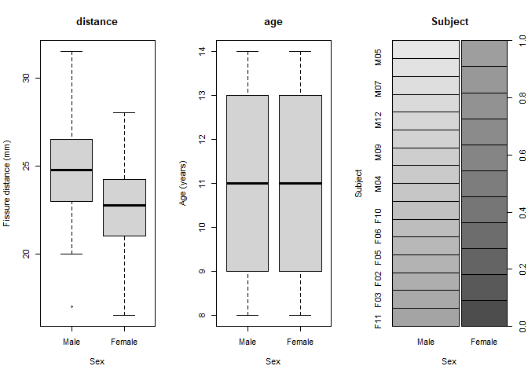

```r
par(mfrow = c(1, 3))
plot(Orthodont, by = "Sex")
```

We can as well plot everything against the metrical variable `distance`

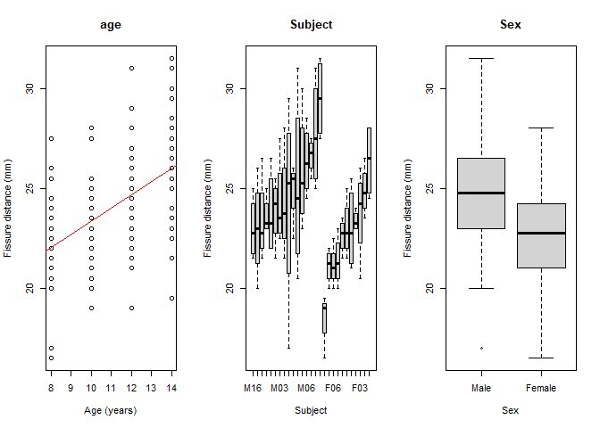

```r
par(mfrow = c(1, 3))
plot(Orthodont, with = "distance")
```

To plot only a subset of the data, say all but `Subject`, against `distance` and suppress the regression line we can use

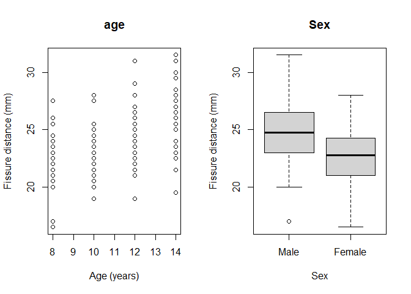

```r
par(mfrow = c(1, 2))
plot(Orthodont, variables = -3, with = "distance", regression.line = FALSE)
```

Note that again we can use either variable names or indices to specify the variables which are to be plotted.

### Summary tables

One can use the command `summarize()` to automatically produce summary tables for either numerical variables (i.e., variables where `is.numeric()` is `TRUE`) or categorical variables (where `is.factor()` is `TRUE`). We now extract a summary table for numerical variables of the `Orthodont` data set:

```r
data(Orthodont, package = "nlme")
summarize(Orthodont, type = "numeric")
```

```
##              N    Mean   SD    Min Q1 Median Q3  Max
## 1 distance 108   24.02 2.93   16.5 22  23.75 26 31.5
## 2      age 108   11.00 2.25    8.0  9  11.00 13 14.0
```

Similarly, we can extract summaries for all factor variables. As one of the factors is the `Subject` which has 27 levels, each with 4 observations, we exclude this from the summary table and only have a look at `Sex`

```r
summarize(Orthodont, type = "factor", variables = "Sex")
```

```
##        Level    N    %
## 1 Sex   Male   64 59.3
## 2     Female   44 40.7
```

Again, as for the plots, one can specify `group`s to obtain grouped statistics:

```r
summarize(Orthodont, type = "numeric", group = "Sex", test = FALSE)
```

```
##               Sex    N    Mean   SD    Min Q1 Median    Q3  Max
## 1 distance   Male   64   24.97 2.90   17.0 23  24.75 26.50 31.5
## 2          Female   44   22.65 2.40   16.5 21  22.75 24.25 28.0
## 3      age   Male   64   11.00 2.25    8.0  9  11.00 13.00 14.0
## 4          Female   44   11.00 2.26    8.0  9  11.00 13.00 14.0
```

Per default, one also gets `test`s for group differences:

```r
summarize(Orthodont, type = "numeric", group = "Sex")
```

```
##               Sex    N    Mean   SD    Min Q1 Median    Q3  Max   p.value
## 1 distance   Male   64   24.97 2.90   17.0 23  24.75 26.50 31.5    <0.001
## 2          Female   44   22.65 2.40   16.5 21  22.75 24.25 28.0
## 3      age   Male   64   11.00 2.25    8.0  9  11.00 13.00 14.0     1.000
## 4          Female   44   11.00 2.26    8.0  9  11.00 13.00 14.0
```

### Converting summaries to PDF

So far, we only got standard R output. Yet, any of these summary tables can be easily converted to LaTeX code using the package **xtable**. In **papeR** two special functions `xtable.summary()` and `print.xtable.summary()` are defined for easy and pretty conversion. In `Sweave` we can use

```r
<<echo = FALSE, results = tex>>=
xtable(summarize(Orthodont, type = "numeric"))
xtable(summarize(Orthodont, type = "factor", variables = "Sex"))
xtable(summarize(Orthodont, type = "numeric", group = "Sex"))
@
```

and in **knitr** we can use

```r
<<echo = FALSE, results = 'asis'>>=
xtable(summarize(Orthodont, type = "numeric"))
xtable(summarize(Orthodont, type = "factor", variables = "Sex"))
xtable(summarize(Orthodont, type = "numeric", group = "Sex"))
@
```

to get the following PDF output

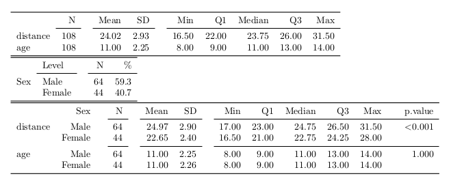

LaTeX Output

Note that per default, `booktabs` is set to `TRUE` in `print.xtable.summary`, and thus `\usepackage{booktabs}` is needed in the header of the LaTeX report. For details on LaTeX summary tables see the dedicated vignette, which can be obtained, e.g., via `vignette("papeR\_with\_latex", package = "papeR")`. See also there for more details on summary tables in general.

### Converting summaries to Markdown

To obtain markdown output we can use, for example, the function `kable()` from package **knitr** on the summary objects:

````r
```{r, echo = FALSE, results = 'asis'}
library("knitr")
kable(summarize(Orthodont, type = "numeric"))
kable(summarize(Orthodont, type = "factor", variables = "Sex", cumulative = TRUE))
kable(summarize(Orthodont, type = "numeric", group = "Sex", test = FALSE))
```
````

which gives the following results

|  | N |  | Mean | SD |  | Min | Q1 | Median | Q3 | Max |
| --- | --- | --- | --- | --- | --- | --- | --- | --- | --- | --- |
| distance | 108 |  | 24.02 | 2.93 |  | 16.5 | 22 | 23.75 | 26 | 31.5 |
| age | 108 |  | 11.00 | 2.25 |  | 8.0 | 9 | 11.00 | 13 | 14.0 |

|  | Level |  | N | % | $\sum$ % |
| --- | --- | --- | --- | --- | --- |
| Sex | Male |  | 64 | 59.3 | 59.3 |
|  | Female |  | 44 | 40.7 | 100.0 |

[output not shown]

### Prettify model output

To prettify the output of a linear model, one can use the function `prettify()`. This function adds confidence intervals, properly prints p-values, adds significance stars to the output (if desired) and additionally adds pretty formatting for factors.

```r
linmod <- lm(distance ~ age + Sex, data = Orthodont)
## Extract pretty summary
(pretty_lm <- prettify(summary(linmod)))
```

```
##                 Estimate CI (lower) CI (upper) Std. Error   t value Pr(>|t|)
## 1 (Intercept) 17.7067130 15.5014071 19.9120189 1.11220946 15.920304   <0.001
## 2         age  0.6601852  0.4663472  0.8540231 0.09775895  6.753194   <0.001
## 3 Sex: Female -2.3210227 -3.2031499 -1.4388955 0.44488623 -5.217115   <0.001
##
## 1 ***
## 2 ***
## 3 ***
```

The resulting table can now be formatted for printing using packages like **xtable** for LaTeX which can be used in `.Rnw` files with the option `results='asis'` (in **knitr**) or `results = tex` (in `Sweave`)

```r
xtable(pretty_lm)
```

In markdown files (`.Rmd`) one can instead use the function `kable()` with the chunk option `results='asis'`. The result looks as follows:

```r
kable(pretty_lm)
```

|  | Estimate | CI (lower) | CI (upper) | Std. Error | t value | Pr(>\|t\|) |  |
| --- | --- | --- | --- | --- | --- | --- | --- |
| (Intercept) | 17.7067130 | 15.5014071 | 19.9120189 | 1.1122095 | 15.920304 | <0.001 | *** |
| age | 0.6601852 | 0.4663472 | 0.8540231 | 0.0977589 | 6.753194 | <0.001 | *** |
| Sex: Female | -2.3210227 | -3.2031499 | -1.4388955 | 0.4448862 | -5.217115 | <0.001 | *** |

#### Supported objects

The function `prettify` is *currently* implemented for objects of the following classes:

- `lm` (linear models)
- `glm` (generalized linear models)
- `coxph` (Cox proportional hazards models)
- `lme` (linear mixed models; implemented in package **nlme**)
- `mer` (linear mixed models; implemented in package **lme4**, version < 1.0)
- `merMod` (linear mixed models; implemented in package **lme4**, version >= 1.0)
- `anova` (anova objects)

## Summary and Outlook

The package is intended to ease reporting of standard data analysis tasks such as descriptive statistics, simple test results, plots and to prettify the output of various statistical models.

**papeR** is under active development. Feature requests, bug reports, or patches, which either add new features or fix bugs, are always welcome. Please use the [GitHub](https://github.com/hofnerb/papeR) page.